# Data Visualization in R

Prof. Harbert

Meeting 4

[home](https://bio331.devbioinformatics.org)

# Cool stuff:

https://aeon.co/amp/videos/watch-a-single-cell-become-a-complete-organism-in-six-pulsing-minutes-of-timelapse?__twitter_impression=true

# Data Visualization

Today we will be using ‘ggplot’, an R package for data visualization. These tools will help you create publication quality plots and figures directly from your R code. If there is one thing that you get out of this class I hope that it is som confidence with these tools.

What is ‘ggplot’? The name refers to the “Grammar of Graphics”. This refers to a structured language for building data visualizations.

## ggplot resources

[Hadley Wickham’s paper](http://vita.had.co.nz/papers/layered-grammar.pdf)

[The Grammar of Graphics Book](https://www.amazon.com/Grammar-Graphics-Statistics-Computing/dp/0387245448/ref=sr_1_1?keywords=grammar+of+graphics&qid=1568209903&s=gateway&sr=8-1)

[R for Data Science – Data Visualization chapter](https://r4ds.had.co.nz/data-visualisation.html)

[ggplot documentation](https://ggplot2.tidyverse.org/reference/)

## Recent news: ggplot in the press

The BBC Visual and Data Journalism team uses R and ggplot to create their publication graphics. A few weeks ago they released their toolbox on [GitHub](https://github.com/bbc/bbplot). More from [Medium](https://medium.com/bbc-visual-and-data-journalism/how-the-bbc-visual-and-data-journalism-team-works-with-graphics-in-r-ed0b35693535)

# Visualization Practice

## Read Census Data

For this section we will read in a table of US Census Demographic data from https://www.kaggle.com/muonneutrino/us-census-demographic-data. Download the file: ‘acs2017_county_data.csv’ (google sign in required on Kaggle).

To read data into R we use: read.table() read.csv() read.delim()

```r
census = read.csv('acs2017_county_data.csv') #check your PATH to this file
head(census)
```

|  | CountyId | State | County | TotalPop | Men | Women | Hispanic | White | Black | Native | Asian | Pacific | VotingAgeCitizen | Income | IncomeErr | IncomePerCap | IncomePerCapErr | Poverty | ChildPoverty | Professional | Service | Office | Construction | Production | Drive | Carpool | Transit | Walk | OtherTransp | … |
| --- | --- | --- | --- | --- | --- | --- | --- | --- | --- | --- | --- | --- | --- | --- | --- | --- | --- | --- | --- | --- | --- | --- | --- | --- | --- | --- | --- | --- | --- | --- |
| 1 | 1001 | Alabama | Autauga County | 55036 | 26899 | 28137 | 2.7 | 75.4 | 18.9 | 0.3 | 0.9 | 0 | 41016 | 55317 | 2838 | 27824 | 2024 | 13.7 | 20.1 | 35.3 | 18.0 | 23.2 | 8.1 | 15.4 | 86.0 | 9.6 | 0.1 | 0.6 | 1.3 | … |
| 2 | 1003 | Alabama | Baldwin County | 203360 | 99527 | 103833 | 4.4 | 83.1 | 9.5 | 0.8 | 0.7 | 0 | 155376 | 52562 | 1348 | 29364 | 735 | 11.8 | 16.1 | 35.7 | 18.2 | 25.6 | 9.7 | 10.8 | 84.7 | 7.6 | 0.1 | 0.8 | 1.1 | … |
| 3 | 1005 | Alabama | Barbour County | 26201 | 13976 | 12225 | 4.2 | 45.7 | 47.8 | 0.2 | 0.6 | 0 | 20269 | 33368 | 2551 | 17561 | 798 | 27.2 | 44.9 | 25.0 | 16.8 | 22.6 | 11.5 | 24.1 | 83.4 | 11.1 | 0.3 | 2.2 | 1.7 | … |
| 4 | 1007 | Alabama | Bibb County | 22580 | 12251 | 10329 | 2.4 | 74.6 | 22.0 | 0.4 | 0.0 | 0 | 17662 | 43404 | 3431 | 20911 | 1889 | 15.2 | 26.6 | 24.4 | 17.6 | 19.7 | 15.9 | 22.4 | 86.4 | 9.5 | 0.7 | 0.3 | 1.7 | … |
| 5 | 1009 | Alabama | Blount County | 57667 | 28490 | 29177 | 9.0 | 87.4 | 1.5 | 0.3 | 0.1 | 0 | 42513 | 47412 | 2630 | 22021 | 850 | 15.6 | 25.4 | 28.5 | 12.9 | 23.3 | 15.8 | 19.5 | 86.8 | 10.2 | 0.1 | 0.4 | 0.4 | … |
| 6 | 1011 | Alabama | Bullock County | 10478 | 5616 | 4862 | 0.3 | 21.6 | 75.6 | 1.0 | 0.7 | 0 | 8212 | 29655 | 5376 | 20856 | 2355 | 28.5 | 50.4 | 19.7 | 17.1 | 18.6 | 14.0 | 30.6 | 73.1 | 15.7 | 0.3 | 6.2 | 1.7 | … |

LOOK BACK: How do you write a table to a new file?

## ggplot2 Graphics

For help and an overview of all of the graphics types that are available in ggplot check out the [R ggplot2 cheatsheet](https://www.rstudio.com/wp-content/uploads/2016/11/ggplot2-cheatsheet-2.1.pdf)

```r
#install.packages('ggplot2')
library(ggplot2)
```

### Recall: Scatterplots using ‘geom_point()’

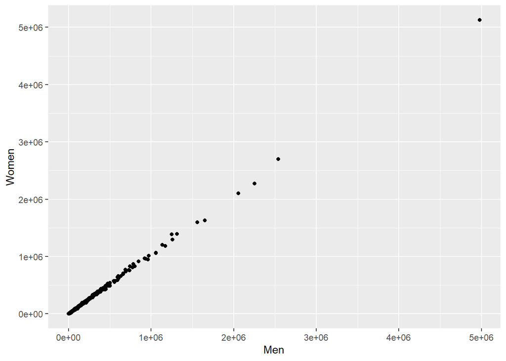

```r
ggplot(data = census) +
  geom_point(mapping = aes(x = Men, y = Women))
```

## Graphs for single parameters:

### geom_histogram()

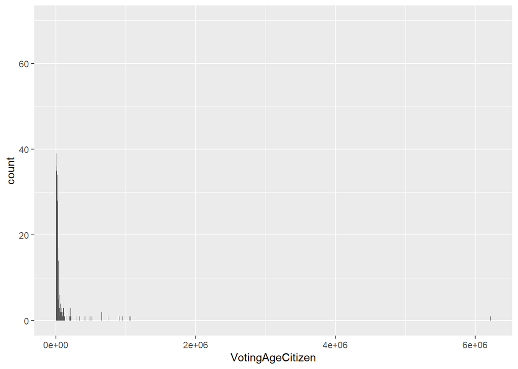

```r
ggplot(data=census) +
  geom_histogram(aes(x=VotingAgeCitizen), binwidth=500)
```

But the x-axis is based on the maximum value, not the effective range so the distribution of the data is tough to read.

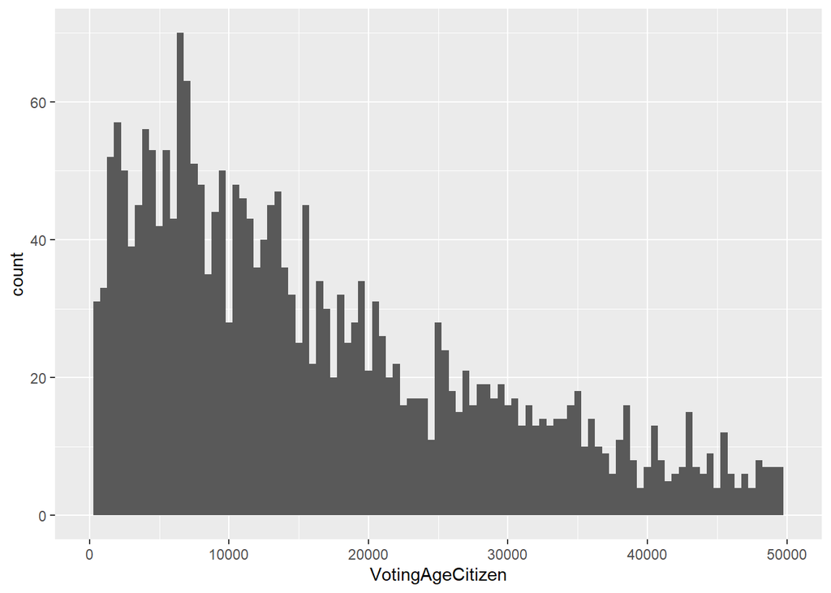

```r
ggplot(data=census) +
  geom_histogram(aes(x=VotingAgeCitizen), binwidth=500)+
  xlim(c(0,50000))
```

### Density:

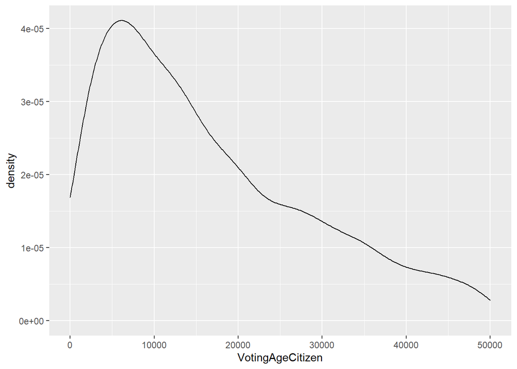

```r
ggplot(data=census) +
  geom_density(aes(x=VotingAgeCitizen)) +
  xlim(c(0,50000))
```

### geom_area()

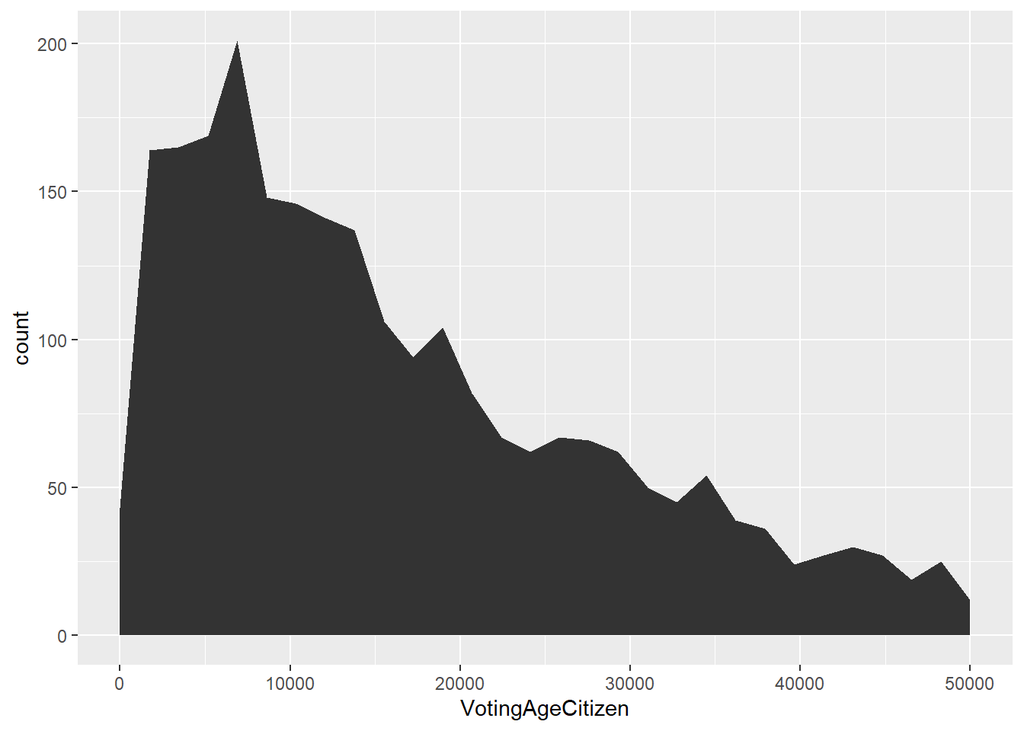

```r
ggplot(data=census) +
  geom_area(stat='bin', bins = 30, aes(x=VotingAgeCitizen)) +
  xlim(c(0,50000))
```

### For Discrete values: geom_bar()

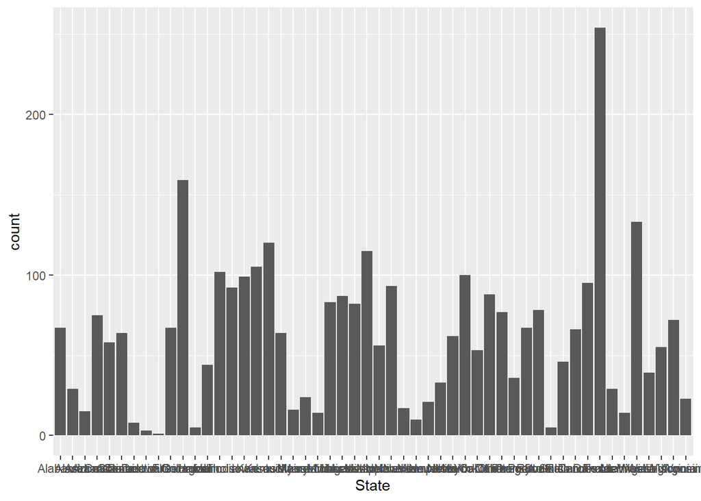

```r
ggplot(data=census) +
  geom_bar(aes(x=State))
```

But, this is hard to read. A few fixes:

- Rotate x-axis labels (Use ‘theme()’)
- Sort states by count (Use library(forcats) – Tools for working with categorical variables)

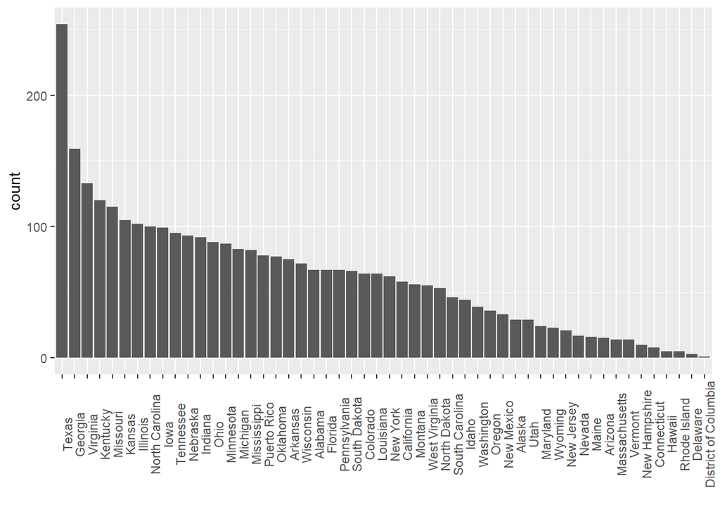

```r
library(forcats)
ggplot(data=census) +
  geom_bar(aes(x=fct_infreq(State))) +
  xlab('') +
  theme(axis.text.x  = element_text(angle=90))
```

### Challenge 1:

Pick a plot method appropriate for the data in the MeanCommute column.

## Graphs for two parameters

### Continuous parameters

#### geom_point()

Scatterplots

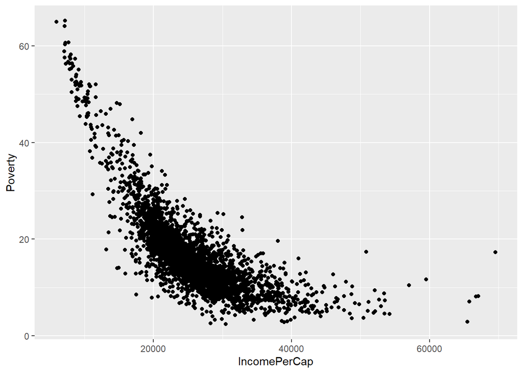

```r
ggplot(data=census) +
    geom_point(aes(x=IncomePerCap, y=Poverty))
```

See also: geom_jitter(), and geom_label()

#### geom_smooth

Add a line

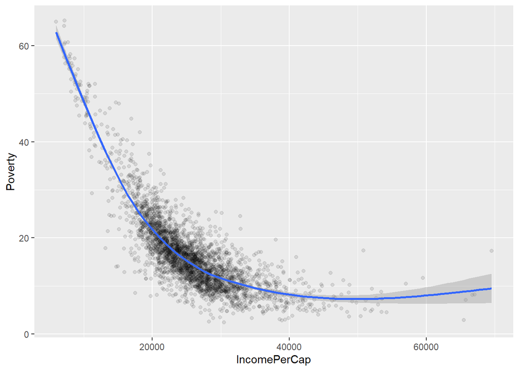

```r
ggplot(data=census) +
    geom_point(aes(x=IncomePerCap, y=Poverty), alpha=0.1) +
    geom_smooth(aes(x=IncomePerCap, y=Poverty))
```

#### Countour and density plots

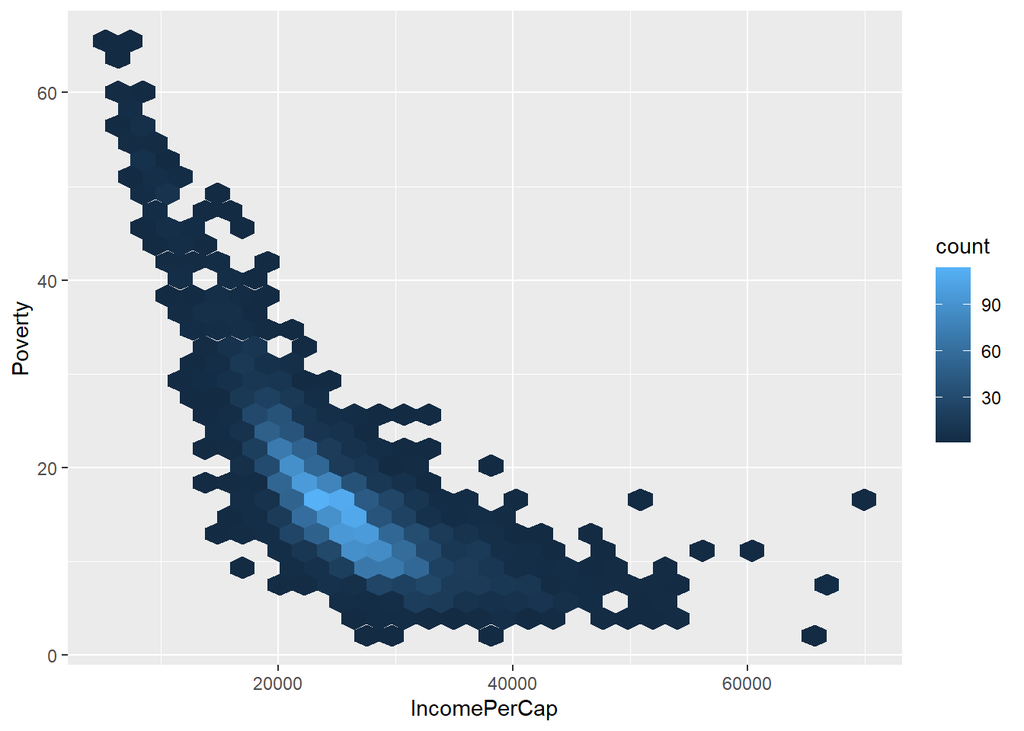

```r
ggplot(data=census) +
    geom_hex(aes(x=IncomePerCap, y=Poverty))
```

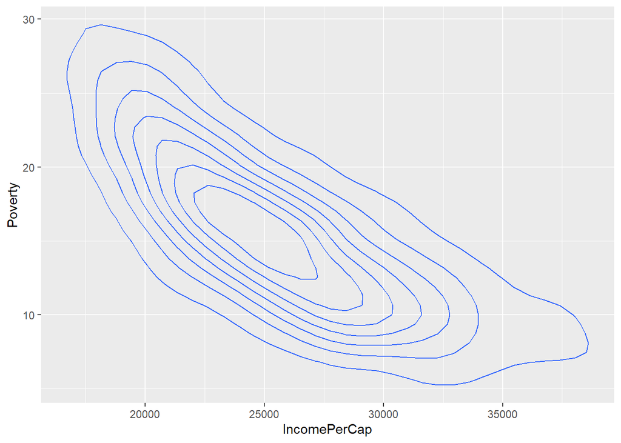

```r
ggplot(data=census) +
    geom_density2d(aes(x=IncomePerCap, y=Poverty))
```

### One Discrete X One Continuous parameter

#### Boxplots

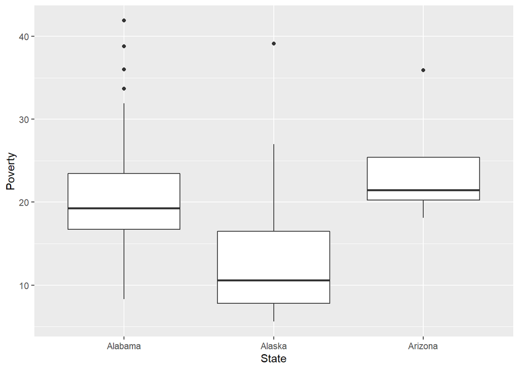

```r
ggplot(data=census[1:100,]) +  #an imperfect sample!
    geom_boxplot(aes(x=State, y=Poverty))
```

#### Violin charts

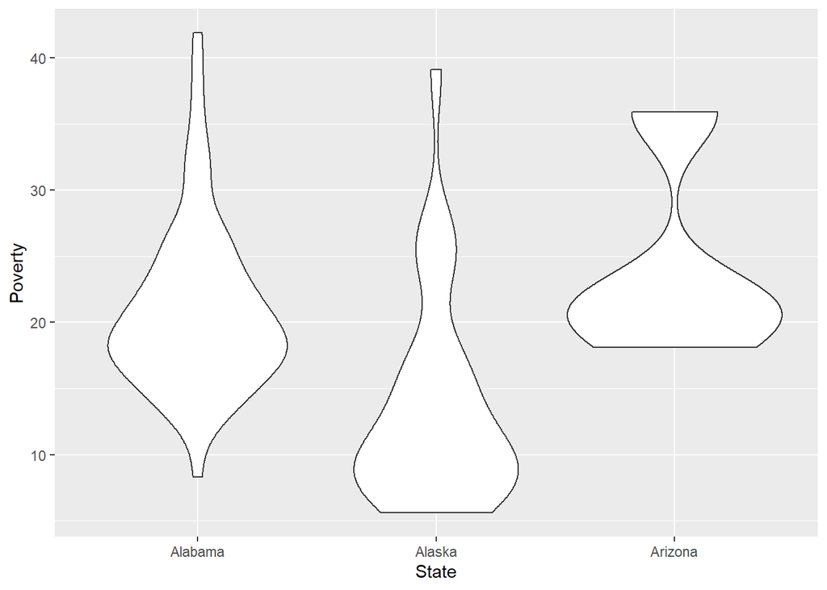

```r
ggplot(data=census[1:100,]) +
    geom_violin(aes(x=State, y=Poverty))
```

## Facetting: Multipanel plots

Plus logical subsetting using the ‘%in%’ operator. (compare matches to a list of values)

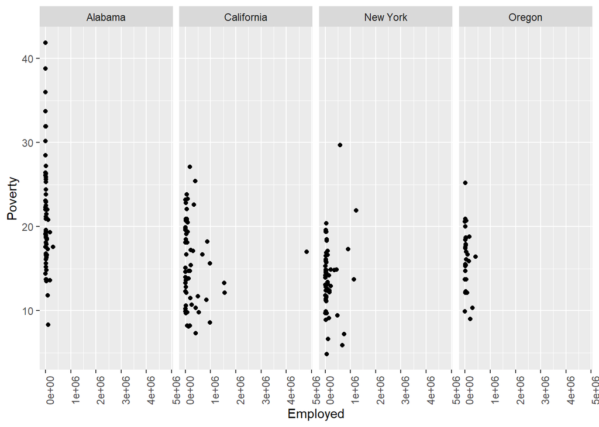

```r
ggplot(data=census[census$State %in% c('Alabama', 'Oregon', 'New York', 'California'),]) +
    geom_point(aes(x=Employed, y=Poverty)) +
    facet_grid(~State) + theme(axis.text.x = element_text(angle=90))
```

### Challenge 2

Develop a plot showing the relationship between MeanCommute and Transit. Then attempt to facet this by State for a subset (use %in%) of five states of your choosing.

# Save your work

You should have been keeping your code in an R script file. Save that file now so that you can refer back to it later.

# Homework

## Part 1

Open a new data file using:

```r
newdata = read.csv('/usr/share/data/classfiles/readlengths3.txt', sep=' ')
```

These data are read lengths for three samples. I want to know how the read length distributions differ between these three samples. The DNA came from fossilized packrat middens dating back up to 3500 years ago and the degree of fragmentation may tell something about the age and/or preservation state of the sample. [Read more about these data here!](https://onlinelibrary.wiley.com/doi/full/10.1002/ece3.6082)

Create a plot showing some attribute of the read length distribution that can be compared between these samples. Bring to next class.

## Part 2

Re-make your plot from last class and post to [#datacoll](https://introbioinformatics.slack.com/archives/C01K1N821PH).

[home](https://bio331.devbioinformatics.org)